# Extracting gene signatures from breast ER+ and prostate cancers

# 2 Classification modeling

Classification by sparse logistic regression.

## 2.1 BRCA/PRAD tumor tissue vs. normal tissue

Combining BRCA and PRAD tumor and normal data into a single data matrix:

```r
# removing variables with sd=0
xbrca_sd <- xbrca[,sapply(seq(ncol(xbrca)), function(ix) {sd(xbrca[,ix])}) != 0]
xprad_sd <- xprad[,sapply(seq(ncol(xprad)), function(ix) {sd(xprad[,ix])}) != 0]

xbrca_less <- xbrca_sd[,which(colnames(xbrca_sd) %in% colnames(xprad_sd))]
xprad_less <- xprad_sd[,which(colnames(xprad_sd) %in% colnames(xbrca_sd))]

xdata <- scale(rbind(log2(xbrca_less+1),log2(xprad_less+1)))
ydata <- c(ybrca,yprad)
ylabel <- c(rep("b",length(ybrca)),rep("p",length(yprad)))

xdata_less <- xdata
```

Building a weight vector that penalizes genes with larger distances between BRCA and PRAD correlation matrices

```r
# normalizing data
xbrca_norm <- scale(log2(xbrca_less+1))
xprad_norm <- scale(log2(xprad_less+1))

xbrca_cor_aux <- xbrca_norm
xprad_cor_aux <- xprad_norm

## correlation matrices

library("propagate")
library("lsa")

xbrca_cor <- bigcor(xbrca_cor_aux, y = NULL, fun = "cor", size = 2000, verbose=FALSE)
xbrca_cor <- as.data.frame(as.ffdf(xbrca_cor))

xprad_cor <- bigcor(xprad_cor_aux, y = NULL, fun = "cor", size = 2000, verbose=FALSE)
xprad_cor <- as.data.frame(as.ffdf(xprad_cor))

# angular distance
ang_weight <- vector()

for (i in 1:dim(xdata_less)[2]){
ang_weight[i] <- acos(cosine(xbrca_cor[,i],xprad_cor[,i]))/pi
}

variables_interest_weight <- which(ang_weight < acos(0.25)/pi)
xdata_less <- xdata[,variables_interest_weight]
brcaprad_weights_netw <- ang_weight[variables_interest_weight]

##normalized weights (between 0 and 1)
brcaprad_weights_netw_norm <- brcaprad_weights_netw / max(brcaprad_weights_netw)
brcaprad_weights_netw <- brcaprad_weights_netw_norm
```

Comparing model predictive performing either using network information or not, based on resampling (100 random train and test samples)

```r
# Performing 100 train and test boostrap samples
times_boot <- 100

nvar_selected_brcaprad_tn <- matrix(0,2,times_boot)
miscl_train_brcaprad_tn <- matrix(0,2,times_boot)
miscl_test_brcaprad_tn <- matrix(0,2,times_boot)
mse_train_brcaprad_tn <- matrix(0,2,times_boot)
mse_test_brcaprad_tn <- matrix(0,2,times_boot)
var_selected <- vector()
var_selected_netw <- vector()
var_selected_idx <- vector()
var_selected_netw_idx <- vector()
pr_auc_train_brcaprad_tn <- matrix(0,2,times_boot)
pr_auc_test_brcaprad_tn <- matrix(0,2,times_boot)

set.seed(1979)

new_test_id_matrix <- matrix(0,round(dim(xdata_less)[1]*0.25),times_boot)

# building random selected training and test sets (25 % assigned for testing)
for (i in 1:times_boot){
new_test_id_matrix[,i] <- sample(1:dim(xdata_less)[1],round(dim(xdata_less)[1]*0.25),replace=FALSE)
}

# assigning samples to folds
set.seed(2010)
my_foldid_brcaprad_tn <- sample(1:10,size=dim(xdata_less[-new_test_id_matrix[,i],])[1]
,replace=TRUE)

for (i in 1:times_boot){

new_xtrain <- xdata_less[-new_test_id_matrix[,i],]
new_ytrain <- ydata[-new_test_id_matrix[,i]]

new_xtest <- xdata_less[new_test_id_matrix[,i],]
new_ytest <- ydata[new_test_id_matrix[,i]]

# Classification by sparse logistic regression

## with the elastic net (EN) penalty

library(glmnet)

fit_EN_cv_brcaprad_tn <- cv.glmnet(new_xtrain, as.factor(new_ytrain), family="binomial", nfolds=10, alpha=0.9, foldid=my_foldid_brcaprad_tn, type.measure="mse")

var_selected_EN_brcaprad_tn_idx <- which(fit_EN_cv_brcaprad_tn$glmnet.fit$beta[,which(fit_EN_cv_brcaprad_tn$cvm == min(fit_EN_cv_brcaprad_tn$cvm))] != 0)

nvar_selected_brcaprad_tn[1,i] <- length(var_selected_EN_brcaprad_tn_idx)

var_selected_idx <- c(var_selected_idx,var_selected_EN_brcaprad_tn_idx)

var_selected <- c(var_selected,as.matrix(mcols(ensembl.protein.coding[colnames(new_xtrain[,var_selected_EN_brcaprad_tn_idx]),2])))

# misclassifications, MSE, ROC and PR

# train set
pred_EN_train_brcaprad_tn <- predict(fit_EN_cv_brcaprad_tn,new_xtrain,type="response")
table(new_ytrain,round(pred_EN_train_brcaprad_tn))
miscl_train_brcaprad_tn[1,i] <- length(which(new_ytrain !=round(pred_EN_train_brcaprad_tn)))

mse_train_brcaprad_tn[1,i] <- mean((new_ytrain - pred_EN_train_brcaprad_tn)^2)

library(PRROC)

pr_auc_train_brcaprad_tn[1,i] <- pr.curve(scores.class0=as.vector(round(pred_EN_train_brcaprad_tn)), weights.class0=new_ytrain)$auc.integral

# test set
pred_EN_test_brcaprad_tn <- predict(fit_EN_cv_brcaprad_tn,new_xtest,type="response")
table(new_ytest,round(pred_EN_test_brcaprad_tn))
miscl_test_brcaprad_tn[1,i] <- length(which(new_ytest !=round(pred_EN_test_brcaprad_tn)))

mse_test_brcaprad_tn[1,i] <- mean((new_ytest - pred_EN_test_brcaprad_tn)^2)

pr_auc_test_brcaprad_tn[1,i] <- pr.curve(scores.class0=as.vector(round(pred_EN_test_brcaprad_tn)), weights.class0=new_ytest)$auc.integral

# with network-based information

fit_ENnetw_cv_brcaprad_tn <- cv.glmnet(new_xtrain, as.factor(new_ytrain), family="binomial", nfolds=10, alpha=0.9, foldid=my_foldid_brcaprad_tn, penalty.factor=brcaprad_weights_netw,type.measure="mse")

var_selected_ENnetw_brcaprad_tn_idx <- which(fit_ENnetw_cv_brcaprad_tn$glmnet.fit$beta[,which(fit_ENnetw_cv_brcaprad_tn$cvm == min(fit_ENnetw_cv_brcaprad_tn$cvm))] != 0)

nvar_selected_brcaprad_tn[2,i] <- length(var_selected_ENnetw_brcaprad_tn_idx)

var_selected_netw_idx <- c(var_selected_netw_idx,var_selected_ENnetw_brcaprad_tn_idx)

var_selected_netw <- c(var_selected_netw,as.matrix(mcols(ensembl.protein.coding[colnames(new_xtrain[,var_selected_ENnetw_brcaprad_tn_idx]),2])))

# misclassifications, MSE, ROC and PR

# train set
pred_ENnetw_train_brcaprad_tn <- predict(fit_ENnetw_cv_brcaprad_tn,new_xtrain,type="response")
table(new_ytrain,round(pred_ENnetw_train_brcaprad_tn))
miscl_train_brcaprad_tn[2,i] <- length(which(new_ytrain !=round(pred_ENnetw_train_brcaprad_tn)))

mse_train_brcaprad_tn[2,i] <- mean((new_ytrain - pred_ENnetw_train_brcaprad_tn)^2)

pr_auc_train_brcaprad_tn[2,i] <- pr.curve(scores.class0=as.vector(round(pred_ENnetw_train_brcaprad_tn)), weights.class0=new_ytrain)$auc.integral

# test set
pred_ENnetw_test_brcaprad_tn <- predict(fit_ENnetw_cv_brcaprad_tn,new_xtest,type="response")
table(new_ytest,round(pred_ENnetw_test_brcaprad_tn))
miscl_test_brcaprad_tn[2,i] <- length(which(new_ytest !=round(pred_ENnetw_test_brcaprad_tn)))

mse_test_brcaprad_tn[2,i] <- mean((new_ytest - pred_ENnetw_test_brcaprad_tn)^2)

pr_auc_test_brcaprad_tn[2,i] <- pr.curve(scores.class0=as.vector(round(pred_ENnetw_test_brcaprad_tn)), weights.class0=new_ytest)$auc.integral

rm(new_xtrain,new_xtest,new_ytrain,new_ytest)
}
```

Summary numbers for each modeling strategy

```r
# median number of variables selected
apply(nvar_selected_brcaprad_tn,1,median)
```

```
## [1] 58.5 67.5
```

```r
# median number of misclassifications in the train set
round(apply(round(miscl_train_brcaprad_tn),1,median))
```

```
## [1] 17 15
```

```r
# median number of misclassifications in the test set
round(apply(round(miscl_test_brcaprad_tn),1,median))
```

```
## [1] 8 9
```

```r
# median squared error in the train set
apply(mse_train_brcaprad_tn,1,median)
```

```
## [1] 0.01310893 0.01222387
```

```r
# median squared error in the test set
apply(mse_test_brcaprad_tn,1,median)
```

```
## [1] 0.01767506 0.01778107
```

```r
# median PR AUC in the train set
apply(pr_auc_train_brcaprad_tn,1,median)
```

```
## [1] 0.9848043 0.9875844
```

```r
# median PR AUC in the test set
apply(pr_auc_test_brcaprad_tn,1,median)
```

```
## [1] 0.9786968 0.9790951
```

```r
# improvement in model predictive performance (MSE) by incorporating network-based information
# train
median((mse_train_brcaprad_tn[1,]-mse_train_brcaprad_tn[2,])*100/mse_train_brcaprad_tn[1,])
```

```
## [1] 11.37658
```

```r
#test
median((mse_test_brcaprad_tn[1,]-mse_test_brcaprad_tn[2,])*100/mse_test_brcaprad_tn[1,])
```

```
## [1] 3.826154
```

Genes selected

```r
# variables always selected by penalized logistic regression in the 100 bootstrap samples
var_selected_alw_select <- as.numeric(names(which(table(var_selected_idx)>99)))
var_selected_alw_select_code <- as.matrix(mcols(ensembl.protein.coding[colnames(xdata_less[,var_selected_alw_select]),2]))
var_selected_alw_select_code
```

```
##                 gene_name
## ENSG00000182492 "BGN"
## ENSG00000188828 "GLRA4"
## ENSG00000189134 "NKAPL"
```

```r
# variables selected in more than 75% of the bootstrap runs by penalized logistic regression
var_selected_75_select <- as.numeric(names(which(table(var_selected_idx)>75)))
var_selected_75_select_code <- as.matrix(mcols(ensembl.protein.coding[colnames(xdata_less[,var_selected_75_select]),2]))
var_selected_75_select_code
```

```
##                 gene_name
## ENSG00000077264 "PAK3"
## ENSG00000124134 "KCNS1"
## ENSG00000124839 "RAB17"
## ENSG00000132002 "DNAJB1"
## ENSG00000140274 "DUOXA2"
## ENSG00000148483 "TMEM236"
## ENSG00000170509 "HSD17B13"
## ENSG00000174611 "KY"
## ENSG00000179796 "LRRC3B"
## ENSG00000180871 "CXCR2"
## ENSG00000182492 "BGN"
## ENSG00000183873 "SCN5A"
## ENSG00000188828 "GLRA4"
## ENSG00000189134 "NKAPL"
## ENSG00000259171 "RP11-903H12.5"
## ENSG00000267699 "RP11-729L2.2"
```

```r
# variables always selected by network-based penalized logistic regression in the 100 bootstrap samples
var_selected_netw_alw_select <- as.numeric(names(which(table(var_selected_netw_idx)>99)))
var_selected_netw_alw_select_code <- as.matrix(mcols(ensembl.protein.coding[colnames(xdata_less[,var_selected_netw_alw_select]),2]))
var_selected_netw_alw_select_code
```

```
##                 gene_name
## ENSG00000077264 "PAK3"
## ENSG00000189134 "NKAPL"
```

```r
# variables selected in more than 75% of the bootstrap runs by network-based penalized logistic regression
var_selected_netw_75_select <- as.numeric(names(which(table(var_selected_netw_idx)>75)))
var_selected_netw_75_select_code <- as.matrix(mcols(ensembl.protein.coding[colnames(xdata_less[,var_selected_netw_75_select]),2]))
var_selected_netw_75_select_code
```

```
##                 gene_name
## ENSG00000077264 "PAK3"
## ENSG00000104888 "SLC17A7"
## ENSG00000105472 "CLEC11A"
## ENSG00000112365 "ZBTB24"
## ENSG00000112972 "HMGCS1"
## ENSG00000148483 "TMEM236"
## ENSG00000163882 "POLR2H"
## ENSG00000164603 "BMT2"
## ENSG00000168079 "SCARA5"
## ENSG00000169826 "CSGALNACT2"
## ENSG00000179796 "LRRC3B"
## ENSG00000180871 "CXCR2"
## ENSG00000183873 "SCN5A"
## ENSG00000188828 "GLRA4"
## ENSG00000189134 "NKAPL"
## ENSG00000259066 "RP11-371E8.4"
## ENSG00000267699 "RP11-729L2.2"
```

```r
# variables selected in common between penalized logistic regression and network-based penalized logistic regression
common_var_selected_netw_75 <- var_selected_netw_75_select[which(var_selected_netw_75_select %in% var_selected_75_select)]
common_var_selected_netw_75
```

```
## [1]  1210  7856 12267 12395 12823 13634 13680 16026
```

```r
common_var_selected_netw_75_code <- var_selected_netw_75_select_code[which(var_selected_netw_75_select_code %in% var_selected_75_select_code)]
common_var_selected_netw_75_code
```

```
## [1] "PAK3"         "TMEM236"      "LRRC3B"       "CXCR2"
## [5] "SCN5A"        "GLRA4"        "NKAPL"        "RP11-729L2.2"
```

```r
# distinct variables selected by penalized logistic regression
distinct_var_selected_75 <- var_selected_75_select[-which(var_selected_75_select %in% var_selected_netw_75_select)]
distinct_var_selected_75
```

```
## [1]  4761  4876  5648  6868 10920 11601 12596 15837
```

```r
distinct_var_selected_75_code <- var_selected_75_select_code[-which(var_selected_75_select_code %in% var_selected_netw_75_select_code)]
distinct_var_selected_75_code
```

```
## [1] "KCNS1"         "RAB17"         "DNAJB1"        "DUOXA2"
## [5] "HSD17B13"      "KY"            "BGN"           "RP11-903H12.5"
```

```r
# distinct variables selected by network-based penalized logistic regression
distinct_var_selected_netw_75 <- var_selected_netw_75_select[-which(var_selected_netw_75_select %in% var_selected_75_select)]
distinct_var_selected_netw_75
```

```
## [1]  2618  2725  3533  3592  9573  9756 10485 10796 15834
```

```r
distinct_var_selected_netw_75_code <- var_selected_netw_75_select_code[-which(var_selected_netw_75_select_code %in% var_selected_75_select_code)]
distinct_var_selected_netw_75_code
```

```
## [1] "SLC17A7"      "CLEC11A"      "ZBTB24"       "HMGCS1"
## [5] "POLR2H"       "BMT2"         "SCARA5"       "CSGALNACT2"
## [9] "RP11-371E8.4"
```

## 2.2 BRCA tumor tissue vs. normal tissue

Building train and test sets:

```r
xbrca_fit_norm <- xbrca_norm

# building training and test sets (25 % assigned for testing)
set.seed(2010)
test_id <- sample(1:dim(xbrca_fit_norm)[1],round(dim(xbrca_fit_norm)[1]*0.25),replace=FALSE)

xtrain <- xbrca_fit_norm[-test_id,]
ytrain <- ybrca[-test_id]

xtest <- xbrca_fit_norm[test_id,]
ytest <- ybrca[test_id]
```

Classification by sparse logistic regression based on the elastic net (EN) penalty

```r
# cross-validation for finding optimum alpha
my_alpha <- seq(0.5,0.9,0.1)

# Optimizing alpha and lambda for logistic regression with Elastic net regularization
nvar_selected_EN_brca <- matrix(0,1,length(my_alpha))
pred_EN_cv_brca <- matrix(0,dim(xtrain)[1],length(my_alpha))
MSE_EN_cv_brca <- matrix(0,1,length(my_alpha))
PR_EN_cv_brca <- matrix(0,1,length(my_alpha))

# assigning samples to folds, to be used in cross-validation when tunning alpha
set.seed(2010)
my_foldid_brca <- sample(1:10,size=length(ytrain),replace=TRUE)

for (j in 1:length(my_alpha)){

    # Logistic model fitting with 10-fold cross-validation for glmnet:
    fit_EN_cv_brca <- cv.glmnet(as.matrix(xtrain),as.factor(ytrain),family="binomial",foldid=my_foldid_brca,alpha=my_alpha[j],type.measure="mse")
    var_selected_EN_brca <- which(fit_EN_cv_brca$glmnet.fit$beta[,which(fit_EN_cv_brca$cvm == min(fit_EN_cv_brca$cvm))] != 0)
    nvar_selected_EN_brca[j] <- length(var_selected_EN_brca)

    # Predictions obtained by model i:
    pred_EN_cv_brca[,j] <- predict(fit_EN_cv_brca,as.matrix(xtrain),s=fit_EN_cv_brca$lambda[which(fit_EN_cv_brca$cvm == min(fit_EN_cv_brca$cvm))],type="response")

    # Mean squared error of prediction (MSE), area under theprecision recall curve:
    MSE_EN_cv_brca[j] <- mean((ytrain-pred_EN_cv_brca[,j])^2)
    PR_EN_cv_brca[j] <- pr.curve(scores.class0=as.vector(round(pred_EN_cv_brca[,j])), weights.class0=ytrain)$auc.integral
}

MSE_EN_cv_brca
```

```
##              [,1]         [,2]         [,3]         [,4]        [,5]
## [1,] 0.0001344055 0.0001264067 0.0001210245 0.0001168448 0.000113262
```

```r
PR_EN_cv_brca
```

```
##      [,1] [,2] [,3] [,4] [,5]
## [1,]    1    1    1    1    1
```

```r
nvar_selected_EN_brca
```

```
##      [,1] [,2] [,3] [,4] [,5]
## [1,]   70   60   51   46   42
```

```r
my_alpha[which(MSE_EN_cv_brca == min(MSE_EN_cv_brca))]
```

```
## [1] 0.9
```

```r
# sparse logistic regression

fit_EN_cv_brca <- cv.glmnet(xtrain, as.factor(ytrain), family="binomial", nfolds=10, alpha=my_alpha[which(MSE_EN_cv_brca == min(MSE_EN_cv_brca))],foldid=my_foldid_brca, type.measure="mse")

var_selected_EN_brca_idx <- which(fit_EN_cv_brca$glmnet.fit$beta[,which(fit_EN_cv_brca$cvm == min(fit_EN_cv_brca$cvm))] != 0)

length(var_selected_EN_brca_idx)
```

```
## [1] 42
```

```r
# variables code
var_selected_EN_brca <- as.matrix(mcols(ensembl.protein.coding[colnames(xtrain[,var_selected_EN_brca_idx]),2]))
var_selected_EN_brca
```

```
##                 gene_name
## ENSG00000004846 "ABCB5"
## ENSG00000018625 "ATP1A2"
## ENSG00000034971 "MYOC"
## ENSG00000065325 "GLP2R"
## ENSG00000077264 "PAK3"
## ENSG00000084453 "SLCO1A2"
## ENSG00000103044 "HAS3"
## ENSG00000103740 "ACSBG1"
## ENSG00000104888 "SLC17A7"
## ENSG00000105664 "COMP"
## ENSG00000115361 "ACADL"
## ENSG00000123500 "COL10A1"
## ENSG00000124440 "HIF3A"
## ENSG00000124743 "KLHL31"
## ENSG00000125869 "LAMP5"
## ENSG00000130032 "PRRG3"
## ENSG00000133800 "LYVE1"
## ENSG00000134389 "CFHR5"
## ENSG00000136842 "TMOD1"
## ENSG00000137463 "MGARP"
## ENSG00000137727 "ARHGAP20"
## ENSG00000149124 "GLYAT"
## ENSG00000153822 "KCNJ16"
## ENSG00000154493 "C10orf90"
## ENSG00000154736 "ADAMTS5"
## ENSG00000162494 "LRRC38"
## ENSG00000163827 "LRRC2"
## ENSG00000165197 "VEGFD"
## ENSG00000167434 "CA4"
## ENSG00000170509 "HSD17B13"
## ENSG00000171819 "ANGPTL7"
## ENSG00000174611 "KY"
## ENSG00000174899 "PQLC2L"
## ENSG00000179796 "LRRC3B"
## ENSG00000180509 "KCNE1"
## ENSG00000182492 "BGN"
## ENSG00000184530 "C6orf58"
## ENSG00000185742 "C11orf87"
## ENSG00000188828 "GLRA4"
## ENSG00000198643 "FAM3D"
## ENSG00000240654 "C1QTNF9"
## ENSG00000248144 "ADH1C"
```

```r
## misclassifications, MSE ROC and PR

# train set
pred_EN_train_brca <- predict(fit_EN_cv_brca,xtrain,s="lambda.min",type="response")
table(ytrain,round(pred_EN_train_brca))
```

```
##
## ytrain   0   1
##      0  57   0
##      1   0 604
```

```r
mse_EN_train_brca <- mean((ytrain - pred_EN_train_brca)^2)
mse_EN_train_brca
```

```
## [1] 0.000113262
```

```r
PR_EN_train_brca <- pr.curve(scores.class0=as.vector(round(pred_EN_train_brca)), weights.class0=ytrain)$auc.integral
PR_EN_train_brca
```

```
## [1] 1
```

```r
# test set
pred_EN_test_brca <- predict(fit_EN_cv_brca,xtest,s="lambda.min",type="response")
table(ytest,round(pred_EN_test_brca))
```

```
##
## ytest   0   1
##     0  22   0
##     1   1 197
```

```r
mse_EN_test_brca <- mean((ytest - pred_EN_test_brca)^2)
mse_EN_test_brca
```

```
## [1] 0.006476163
```

```r
PR_EN_test_brca <- pr.curve(scores.class0=as.vector(round(pred_EN_test_brca)), weights.class0=ytest)$auc.integral
PR_EN_test_brca
```

```
## [1] 0.9997382
```

## 2.3 PRAD tumor tissue vs. normal tissue

Building train and test sets:

```r
xprad_fit_norm <- xprad_norm

# building training and test sets (25 % assigned for testing)
set.seed(2010)
test_id <- sample(1:dim(xprad_fit_norm)[1],round(dim(xprad_fit_norm)[1]*0.25),replace=FALSE)

xtrain <- xprad_fit_norm[-test_id,]
ytrain <- yprad[-test_id]

xtest <- xprad_fit_norm[test_id,]
ytest <- yprad[test_id]
```

Classification by sparse logistic regression based on the elastic net (EN) penalty

```r
# cross-validation for finding optimum alpha
my_alpha <- seq(0.5,0.9,0.1)

# Optimizing alpha and lambda for logistic regression with Elastic net regularization
nvar_selected_EN_prad <- matrix(0,1,length(my_alpha))
pred_EN_cv_prad <- matrix(0,dim(xtrain)[1],length(my_alpha))
MSE_EN_cv_prad <- matrix(0,1,length(my_alpha))
PR_EN_cv_prad <- matrix(0,1,length(my_alpha))

# assigning samples to folds, to be used in cross-validation when tunning alpha
set.seed(2010)
my_foldid_prad <- sample(1:10,size=length(ytrain),replace=TRUE)

for (j in 1:length(my_alpha)){

    # Logistic model fitting with 10-fold cross-validation for glmnet:
    fit_EN_cv_prad <- cv.glmnet(as.matrix(xtrain),as.factor(ytrain),family="binomial",foldid=my_foldid_prad,alpha=my_alpha[j],type.measure="mse")
    var_selected_EN_prad <- which(fit_EN_cv_prad$glmnet.fit$beta[,which(fit_EN_cv_prad$cvm == min(fit_EN_cv_prad$cvm))] != 0)
    nvar_selected_EN_prad[j] <- length(var_selected_EN_prad)

    # Predictions obtained by model i:
    pred_EN_cv_prad[,j] <- predict(fit_EN_cv_prad,as.matrix(xtrain),s=fit_EN_cv_prad$lambda[which(fit_EN_cv_prad$cvm == min(fit_EN_cv_prad$cvm))],type="response")

    # Mean squared error of prediction (MSE), area under the precision recall curve:
    MSE_EN_cv_prad[j] <- mean((ytrain-pred_EN_cv_prad[,j])^2)
    PR_EN_cv_prad[j] <- pr.curve(scores.class0=as.vector(round(pred_EN_cv_prad[,j])), weights.class0=ytrain)$auc.integral
}

MSE_EN_cv_prad
```

```
##            [,1]       [,2]       [,3]       [,4]       [,5]
## [1,] 0.01871774 0.01943091 0.02016485 0.01994607 0.01884475
```

```r
PR_EN_cv_prad
```

```
##           [,1]      [,2]      [,3]      [,4]      [,5]
## [1,] 0.9735891 0.9735891 0.9735891 0.9735891 0.9735891
```

```r
nvar_selected_EN_prad
```

```
##      [,1] [,2] [,3] [,4] [,5]
## [1,]   68   58   48   43   41
```

```r
my_alpha[which(MSE_EN_cv_prad == min(MSE_EN_cv_prad))]
```

```
## [1] 0.5
```

```r
# sparse logistic regression

fit_EN_cv_prad <- cv.glmnet(xtrain, as.factor(ytrain), family="binomial", nfolds=10, alpha=my_alpha[which(MSE_EN_cv_prad == min(MSE_EN_cv_prad))],foldid=my_foldid_prad, type.measure="mse")

var_selected_EN_prad_idx <- which(fit_EN_cv_prad$glmnet.fit$beta[,which(fit_EN_cv_prad$cvm == min(fit_EN_cv_prad$cvm))] != 0)

length(var_selected_EN_prad_idx)
```

```
## [1] 68
```

```r
# variables code
var_selected_EN_prad <- as.matrix(mcols(ensembl.protein.coding[colnames(xtrain[,var_selected_EN_prad_idx]),2]))
var_selected_EN_prad
```

```
##                 gene_name
## ENSG00000023608 "SNAPC1"
## ENSG00000052802 "MSMO1"
## ENSG00000062096 "ARSF"
## ENSG00000102271 "KLHL4"
## ENSG00000105707 "HPN"
## ENSG00000109181 "UGT2B10"
## ENSG00000109534 "GAR1"
## ENSG00000112761 "WISP3"
## ENSG00000114790 "ARHGEF26"
## ENSG00000116560 "SFPQ"
## ENSG00000118298 "CA14"
## ENSG00000119938 "PPP1R3C"
## ENSG00000122965 "RBM19"
## ENSG00000124587 "PEX6"
## ENSG00000124839 "RAB17"
## ENSG00000125462 "C1orf61"
## ENSG00000125998 "FAM83C"
## ENSG00000128011 "LRFN1"
## ENSG00000130203 "APOE"
## ENSG00000130208 "APOC1"
## ENSG00000132002 "DNAJB1"
## ENSG00000138134 "STAMBPL1"
## ENSG00000140274 "DUOXA2"
## ENSG00000140678 "ITGAX"
## ENSG00000140873 "ADAMTS18"
## ENSG00000142544 "CTU1"
## ENSG00000145309 "CABS1"
## ENSG00000147912 "FBXO10"
## ENSG00000150722 "PPP1R1C"
## ENSG00000151117 "TMEM86A"
## ENSG00000151364 "KCTD14"
## ENSG00000152503 "TRIM36"
## ENSG00000152944 "MED21"
## ENSG00000159263 "SIM2"
## ENSG00000161904 "LEMD2"
## ENSG00000162592 "CCDC27"
## ENSG00000162779 "AXDND1"
## ENSG00000165443 "PHYHIPL"
## ENSG00000165646 "SLC18A2"
```

[output cut: 14 more lines]

```
## ENSG00000183248 "PRR36"
## ENSG00000183317 "EPHA10"
## ENSG00000187288 "CIDEC"
## ENSG00000187658 "C5orf52"
## ENSG00000189134 "NKAPL"
## ENSG00000197360 "ZNF98"
## ENSG00000204370 "SDHD"
## ENSG00000205903 "ZNF316"
## ENSG00000213424 "KRT222"
## ENSG00000242110 "AMACR"
## ENSG00000253250 "C8orf88"
## ENSG00000256646 "RP11-111K18.1"
## ENSG00000270647 "TAF15"
## ENSG00000276040 "SPATA31A7"
## ENSG00000277556 "OR13C5"
```

```r
## misclassifications, MSE ROC and PR

# train set
pred_EN_train_prad <- predict(fit_EN_cv_prad,xtrain,s="lambda.min",type="response")
table(ytrain,round(pred_EN_train_prad))
```

```
##
## ytrain   0   1
##      0  29  10
##      1   1 370
```

```r
mse_EN_train_prad <- mean((ytrain - pred_EN_train_prad)^2)
mse_EN_train_prad
```

```
## [1] 0.01871774
```

```r
PR_EN_train_prad <- pr.curve(scores.class0=as.vector(round(pred_EN_train_prad)), weights.class0=ytrain)$auc.integral
PR_EN_train_prad
```

```
## [1] 0.9735891
```

```r
# test set
pred_EN_test_prad <- predict(fit_EN_cv_prad,xtest,s="lambda.min",type="response")
table(ytest,round(pred_EN_test_prad))
```

```
##
## ytest   0   1
##     0   9   4
##     1   2 122
```

```r
mse_EN_test_prad <- mean((ytest - pred_EN_test_prad)^2)
mse_EN_test_prad
```

```
## [1] 0.03090641
```

```r
PR_EN_test_prad <- pr.curve(scores.class0=as.vector(round(pred_EN_test_prad)), weights.class0=ytest)$auc.integral
PR_EN_test_prad
```

```
## [1] 0.9677305
```

Comparison between BRCAPRAD and BRCA nd PRAD models

```r
# variables in common between network-based logistic regression and individual BRCA and PRAD models
# BRCA
var_selected_netw_75_select_code[which(var_selected_netw_75_select_code %in% var_selected_EN_brca)]
```

```
## [1] "PAK3"    "SLC17A7" "LRRC3B"  "GLRA4"
```

```r
# PRAD
var_selected_netw_75_select_code[which(var_selected_netw_75_select_code %in% var_selected_EN_prad)]
```

```
## [1] "NKAPL"
```

```r
# variables in common between those exclusively selected by network-based logistic regression and individual BRCA and PRAD models
# BRCA
distinct_var_selected_netw_75_code[which(distinct_var_selected_netw_75_code %in% var_selected_EN_brca)]
```

```
## [1] "SLC17A7"
```

```r
# PRAD
distinct_var_selected_netw_75_code[which(distinct_var_selected_netw_75_code %in% var_selected_EN_prad)]
```

```
## character(0)
```

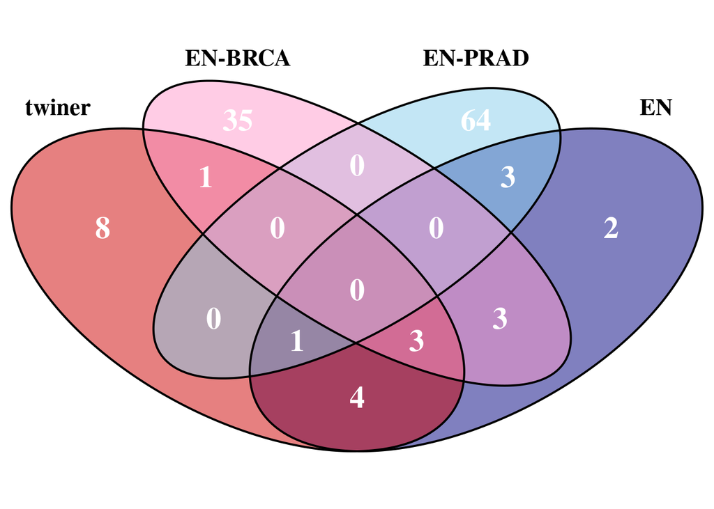

```r
# Venn diagram
library("VennDiagram")
venn_diagram <- venn.diagram( x = list( "twiner" = var_selected_netw_75_select_code, "EN" = var_selected_75_select_code, "EN-BRCA" = var_selected_EN_brca, "EN-PRAD" = var_selected_EN_prad), imagetype="png", filename = NULL, cat.fontface="bold", cat.cex=1.4, palette="ggplot2", label.col = c("white", "white", "white", "white", "white", "white", "white", "white", "white", "white", "white", "white", "white", "white", "white"), fontface="bold",cex = 1.8, fill = c("red3", "navyblue", "#FF99CC", "skyblue"))
grid.draw(venn_diagram)
```

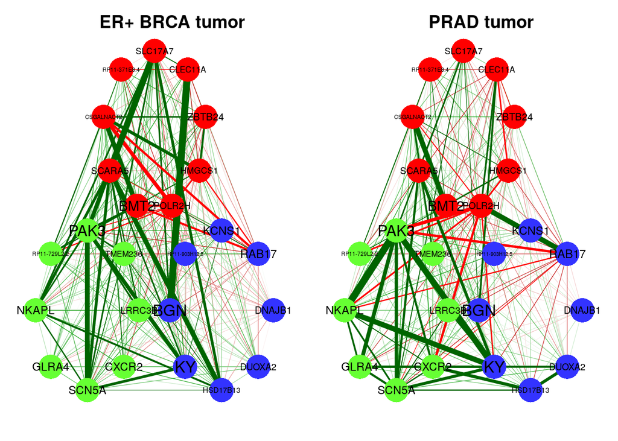

```r
# Gene networks
qgraph_matrix <- xdata_less
qgraph_vars <- c(var_selected_netw_75_select[-which(var_selected_netw_75_select %in% var_selected_75_select)],var_selected_75_select[-which(var_selected_75_select %in% var_selected_netw_75_select)],var_selected_netw_75_select[which(var_selected_netw_75_select %in% var_selected_75_select)])

# BRCA tumor
qgraph_cor_brca_tumor <- cor(qgraph_matrix[ylabel=="b" & ydata=="1",qgraph_vars], method="pearson")
qgraph_cor_brca_normal <- cor(qgraph_matrix[ylabel=="b" & ydata=="0",qgraph_vars], method="pearson")

qgraph_label <- c(distinct_var_selected_netw_75_code,distinct_var_selected_75_code,common_var_selected_netw_75_code)

qgraph_groups <- list(netEN = c(1:length(distinct_var_selected_netw_75_code)), EN = (length(distinct_var_selected_netw_75_code)+1):(length(distinct_var_selected_netw_75_code)+length(distinct_var_selected_75_code)), common = (length(distinct_var_selected_75_code)+length(distinct_var_selected_netw_75_code)+1):(length(distinct_var_selected_75_code)+length(distinct_var_selected_netw_75_code)+length(common_var_selected_netw_75_code)))

# PRAD tumor
qgraph_cor_prad_tumor <- cor(qgraph_matrix[ylabel=="p" & ydata=="1",qgraph_vars], method="pearson")
qgraph_cor_prad_normal <- cor(qgraph_matrix[ylabel=="p" & ydata=="0",qgraph_vars], method="pearson")

library(qgraph)

par(mfrow=c(1, 2))
qgraph(qgraph_cor_brca_tumor, minimum = 0, vsize = 1.5, groups = qgraph_groups, legend=FALSE,borders = FALSE, node.width=4, color=c("#FF0000","#3333FF","#66FF33"),labels = qgraph_label, label.cex=2)
title("ER+ BRCA tumor", line = 2.5)
qgraph(qgraph_cor_prad_tumor, minimum = 0, vsize = 1.5, groups = qgraph_groups, legend=FALSE,borders = FALSE, node.width=4, color=c("#FF0000","#3333FF","#66FF33"),labels = qgraph_label, label.cex=2)
title("PRAD tumor", line = 2.5)
```

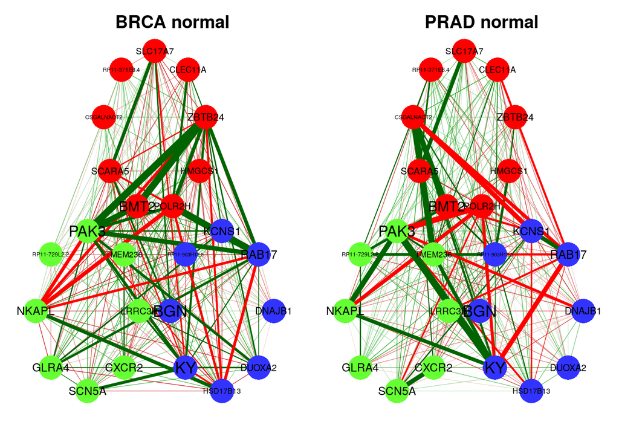

```r
par(mfrow=c(1, 2))#,oma=c(0,0,0,0))
qgraph(qgraph_cor_brca_normal, minimum = 0, vsize = 1.5, groups = qgraph_groups, legend=FALSE,borders = FALSE, node.width=4, color=c("#FF0000","#3333FF","#66FF33"),labels = qgraph_label, label.cex=2)
title("BRCA normal", line = 2.5)
qgraph(qgraph_cor_prad_normal, minimum = 0, vsize = 1.5, groups = qgraph_groups, legend=FALSE,borders = FALSE, node.width=4, color=c("#FF0000","#3333FF","#66FF33"),labels = qgraph_label, label.cex=2)
title("PRAD normal", line = 2.5)
```

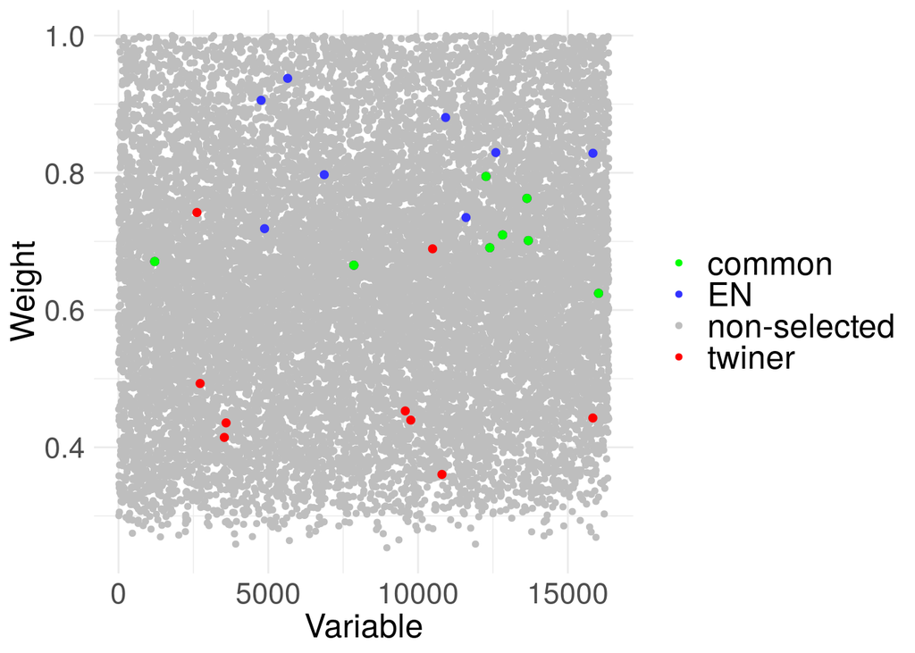

```r
# weights associated to the above selected variables
brcaprad_weights_col <- matrix(1,1,length(brcaprad_weights_netw))
brcaprad_weights_col[var_selected_75_select] <- "EN"
brcaprad_weights_col[var_selected_netw_75_select] <- "twiner"
brcaprad_weights_col[var_selected_75_select[which(var_selected_75_select %in% var_selected_netw_75_select)]] <- "common"
brcaprad_weights_col[brcaprad_weights_col ==1] <-"non-selected"

brcaprad_weights_selected_common_plot <- data.frame(Variable = var_selected_75_select[which(var_selected_75_select %in% var_selected_netw_75_select)], Weight = brcaprad_weights_netw[var_selected_75_select[which(var_selected_75_select %in% var_selected_netw_75_select)]], label = factor(brcaprad_weights_col[var_selected_75_select[which(var_selected_75_select %in% var_selected_netw_75_select)]]))

brcaprad_weights_selected_EN_plot <- data.frame(Variable = var_selected_75_select, Weight = brcaprad_weights_netw[var_selected_75_select], label = factor(brcaprad_weights_col[var_selected_75_select]))

brcaprad_weights_selected_netEN_plot <- data.frame(Variable = var_selected_netw_75_select, Weight = brcaprad_weights_netw[var_selected_netw_75_select], label = factor(brcaprad_weights_col[var_selected_netw_75_select]))

brcaprad_weights_plot <- data.frame(Variable = c(1:length(brcaprad_weights_netw)), Weight = brcaprad_weights_netw, label = factor(brcaprad_weights_col))

library(ggplot2)

ggplot(brcaprad_weights_plot, aes(Variable, Weight)) + geom_point(aes(color = label),size=1.2) +
scale_colour_manual(values=c("#00FF00","#3333FF","gray","#FF0000","#00FF00","#00FF00","#3333FF","#FF0000","#00FF00"))+
theme_minimal()+theme(axis.text=element_text(size=16),axis.title=element_text(size=18),legend.title = element_text(size=14, color="white"),legend.text = element_text(size=18))+  geom_point(data=brcaprad_weights_selected_common_plot,aes(x=Variable, y=Weight), col="#00FF00",size=1.7) +
geom_point(data=brcaprad_weights_selected_netEN_plot,aes(x=Variable, y=Weight), col="#FF0000",size=1.7) +  geom_point(data=brcaprad_weights_selected_EN_plot,aes(x=Variable, y=Weight), col="#3333FF",size=1.7) +  geom_point(data=brcaprad_weights_selected_common_plot,aes(x=Variable, y=Weight), col="#00FF00",size=1.7)
```

```r
# variables selected by network-based sparse logistic regression only, with weights lower than 0.5, i.e., with more similar correlation pattern within brca and prad data sets
as.matrix(mcols(ensembl.protein.coding[colnames(xdata_less[,var_selected_netw_75_select[which(brcaprad_weights_netw[var_selected_netw_75_select] < 0.5)]])]))
```

```
##                 gene_id           gene_name      gene_biotype
## ENSG00000105472 "ENSG00000105472" "CLEC11A"      "protein_coding"
## ENSG00000112365 "ENSG00000112365" "ZBTB24"       "protein_coding"
## ENSG00000112972 "ENSG00000112972" "HMGCS1"       "protein_coding"
## ENSG00000163882 "ENSG00000163882" "POLR2H"       "protein_coding"
## ENSG00000164603 "ENSG00000164603" "BMT2"         "protein_coding"
## ENSG00000169826 "ENSG00000169826" "CSGALNACT2"   "protein_coding"
## ENSG00000259066 "ENSG00000259066" "RP11-371E8.4" "protein_coding"
```

Survival analysis

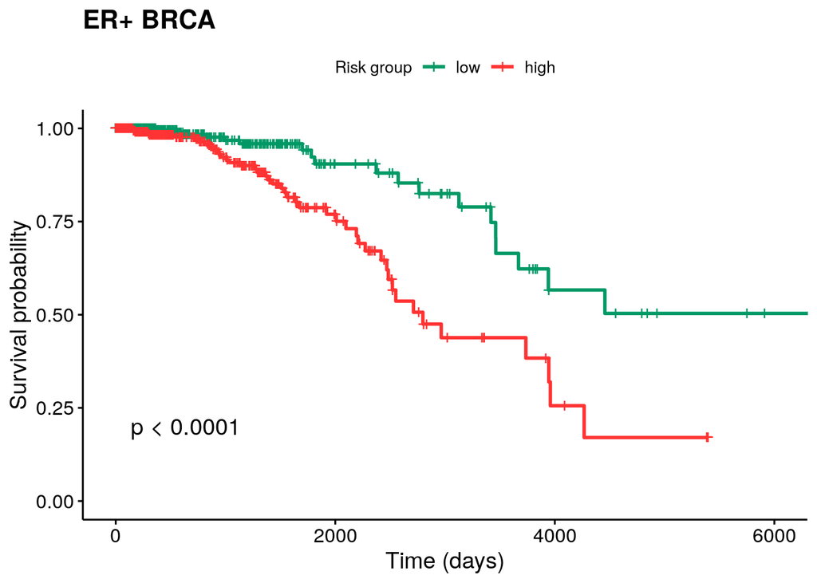

```r
library(survival)
library(survminer)

# BRCA
xbrca_cox <- brca_tumor_erplus[,colnames(xdata_less)]
xbrca_cox <- xbrca_cox[,var_selected_netw_75_select]
xbrca_cox <- scale(log2(xbrca_cox+1))
xbrca_cox_mat <- cbind(brca_survival_status,xbrca_cox)
brca_fit_cox <- coxph(Surv(days_to_death,as.numeric(vital_status)) ~ .,data=as.data.frame(xbrca_cox_mat))

brca_fit_cox_coefficients <- as.matrix(xbrca_cox) %*% brca_fit_cox$coefficients

brca_fit_cox_risk_group <- brca_fit_cox_coefficients
brca_fit_cox_risk_group[which(brca_fit_cox_coefficients > median(brca_fit_cox_coefficients))] <- 2
brca_fit_cox_risk_group[which(brca_fit_cox_coefficients <= median(brca_fit_cox_coefficients))] <- 1

brca_KM_mat <- as.data.frame(cbind(brca_survival_status[,1],brca_survival_status[,2],brca_fit_cox_risk_group))
names(brca_KM_mat) <- c("survival","status","riskgroup")
fit_KM <- survfit(Surv(as.numeric(survival),status) ~ riskgroup, data=brca_KM_mat, type="kaplan-meier", conf.type="plain")
ggsurvplot(fit_KM,title="ER+ BRCA",font.main = c(16, "bold", "black"),legend.labs = c("low","high"), legend.title = "Risk group",pval=TRUE,palette = c("#009966","#FF3333"), xlab= "Time (days)")
```

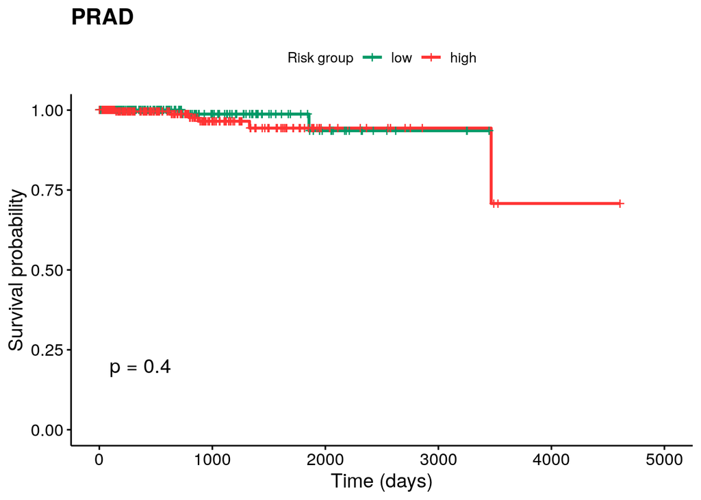

```r
# PRAD
xprad_cox <- prad_tumor[,colnames(xdata_less)]
xprad_cox <- xprad_cox[,var_selected_75_select]
xprad_cox <- scale(log2(xprad_cox+1))
xprad_cox_mat <- cbind(prad_survival_status,xprad_cox)
prad_fit_cox <- coxph(Surv(days_to_death,as.numeric(vital_status)) ~ .,data=as.data.frame(xprad_cox_mat))

prad_fit_cox_coefficients <- as.matrix(xprad_cox) %*% prad_fit_cox$coefficients

prad_fit_cox_risk_group <- prad_fit_cox_coefficients
prad_fit_cox_risk_group[which(prad_fit_cox_coefficients > median(prad_fit_cox_coefficients))] <- 2
prad_fit_cox_risk_group[which(prad_fit_cox_coefficients <= median(prad_fit_cox_coefficients))] <- 1

prad_KM_mat <- as.data.frame(cbind(prad_survival_status[,1],as.numeric(prad_survival_status[,2]),prad_fit_cox_risk_group))
names(prad_KM_mat) <- c("survival","status","riskgroup")

fit_KM <- survfit(Surv(as.numeric(survival),status) ~ riskgroup, data=prad_KM_mat, type="kaplan-meier", conf.type="plain")

ggsurvplot(fit_KM,title="PRAD",font.main = c(16, "bold", "black"),legend.labs = c("low","high"), legend.title = "Risk group",pval=TRUE,palette = c("#009966","#FF3333"), xlab= "Time (days)")
```